# Lab 05

The format of this lab follows the same format as the previous ones. Your goal is to predict the value of the third column (which will be missing on the test set) using the techniques we have learned so far.

# Set up

```r
library(readr)
library(dplyr)
```

```r
library(ggplot2)
library(viridis)
ca <- read_csv("https://statsmaths.github.io/ml_data/ca_house_price.csv")
```

Notice that the test set here is not a random subset of the data but has very different properties that than the other variables.

# Lab 05

The `gam` model using the lowess smoother with the spatial variables works very well in my notes. I ran a model with the lowess smoother on mean and median income and that worked even better. The obvious thing to try then is to use both of these in the same additive model:

```r
library(gam)
model <- gam(median_house_value ~ lo(longitude, latitude) +
               lo(mean_household_income, median_household_income),
             data = ca,
             subset = (train_id == "train"))
ca$price_pred <- predict(model, newdata = ca)
sqrt(tapply((ca$median_house_value - ca$price_pred)^2,
            ca$train_id, mean))
```

```
##     test    train    valid
##       NA 105811.1 108678.2
```

There are some warnings about numerical issues, but the results still looks excellent compared to our other models.

I played around with other two-way interactions but did not find anything particularly interesting. I settled on adding univariate smoothing of a few variables that seemed interesting (mostly based on thinking about the data rather than empirical findings). I also created a vacant percentage variable:

```r
library(gam)
ca$vacant_percent <- ca$vacant_units / ca$total_units
model <- gam(median_house_value ~ lo(longitude, latitude) +
               lo(mean_household_income, median_household_income) +
               s(median_rooms) + s(population) + s(built_2005_or_later) +
               s(mean_household_size_owners) + s(mean_household_size_renters) +
               s(owners) + s(vacant_percent),
             data = ca,
             subset = (train_id == "train"))
ca$price_pred <- predict(model, newdata = ca)
sqrt(tapply((ca$median_house_value - ca$price_pred)^2,
            ca$train_id, mean))
```

```
##     test    train    valid
##       NA 93349.54 97801.24
```

Much better! It doesn’t appear that the model is overfitting too much yet, but it is starting to show a faster decrease in RMSE in the training set relative to the validation set. As a final tweak, I played around with the span arguments of the spatial and income components:

```r
library(gam)
ca$vacant_percent <- ca$vacant_units / ca$total_units
model <- gam(median_house_value ~ lo(longitude, latitude, span = 0.02) +
               lo(mean_household_income, median_household_income) +
               s(median_rooms) + s(population) + s(built_2005_or_later) +
               s(mean_household_size_owners) + s(mean_household_size_renters) +
               s(owners) + s(vacant_percent),
             data = ca,
             subset = (train_id == "train"))
ca$price_pred <- predict(model, newdata = ca)
sqrt(tapply((ca$median_house_value - ca$price_pred)^2,
            ca$train_id, mean))
```

```
##     test    train    valid
##       NA 76038.19 82641.37
```

Its possible to plot the `gam` model using the `plot` function:

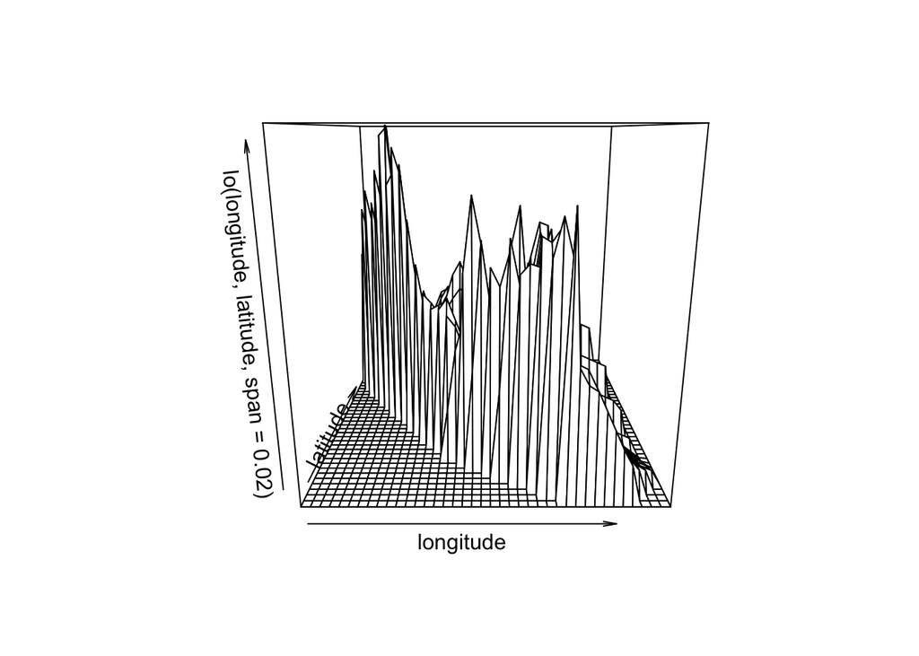

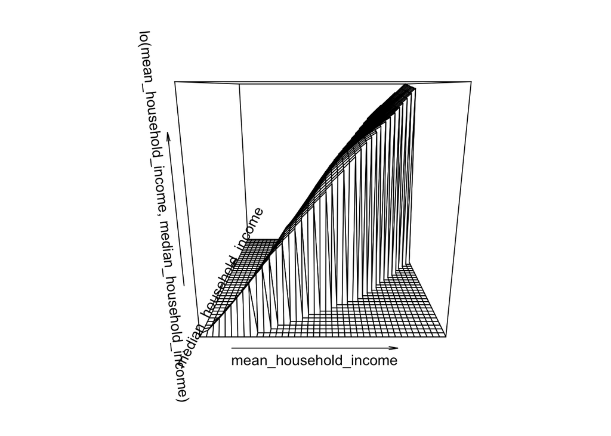

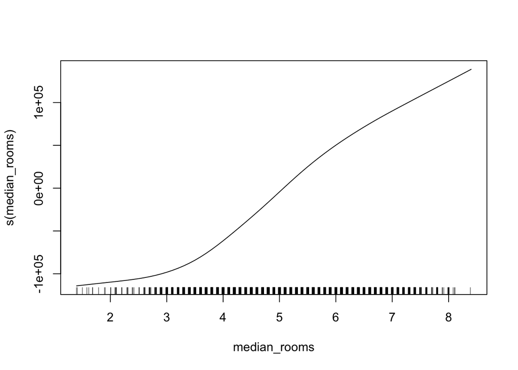

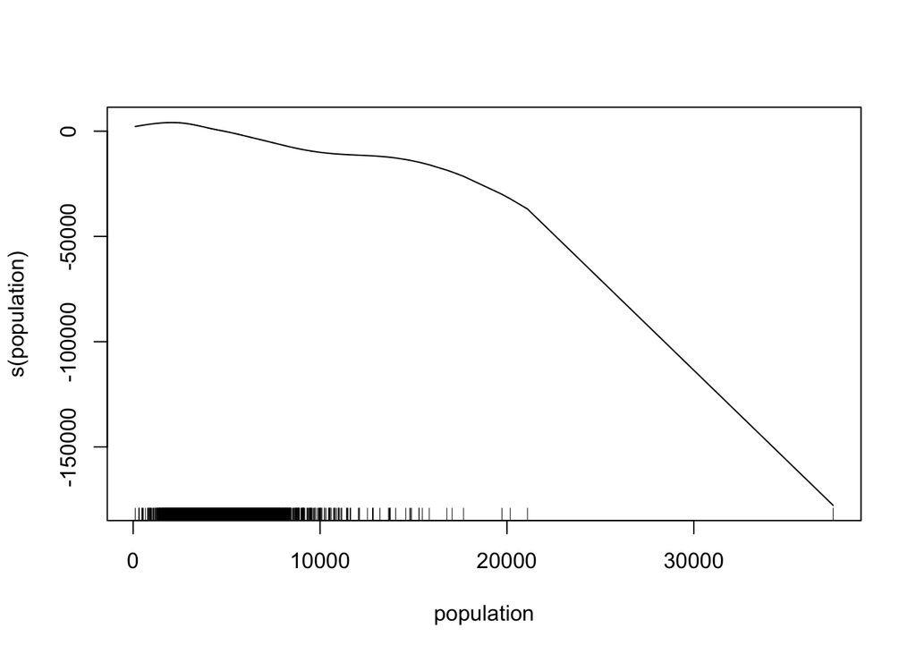

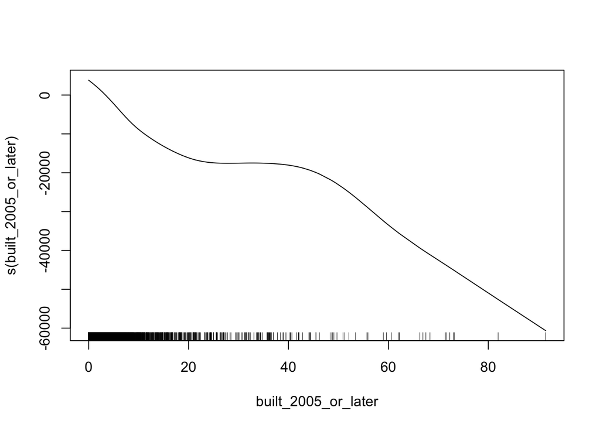

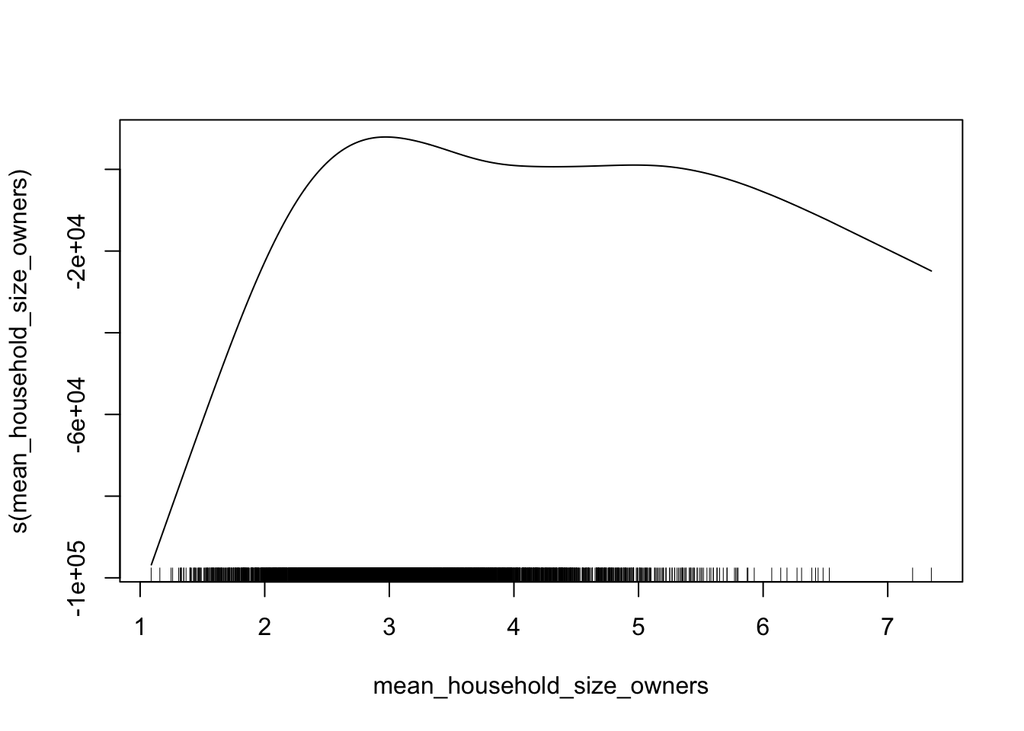

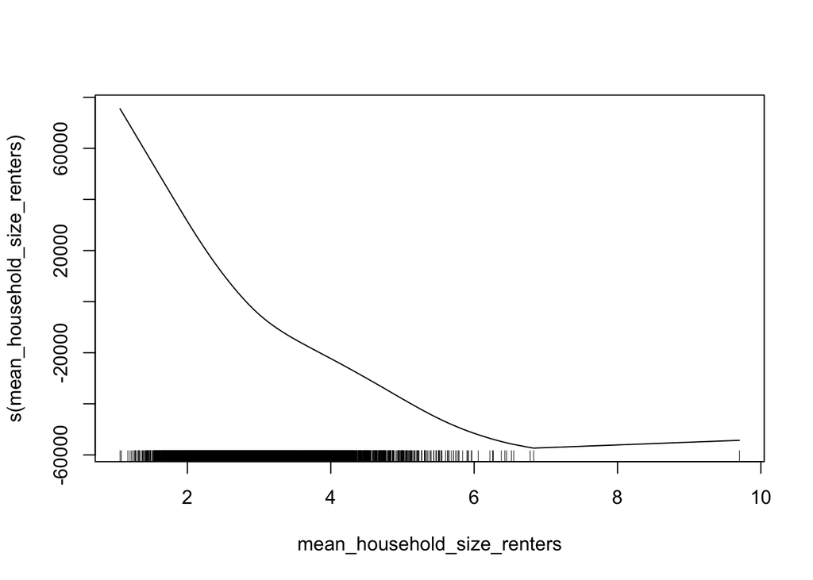

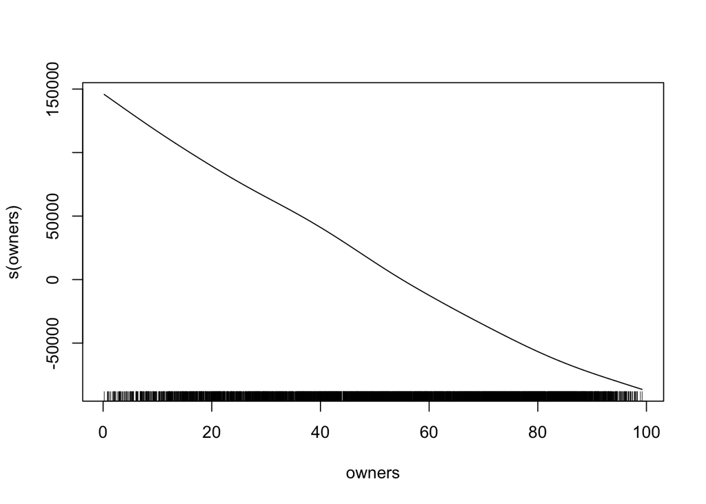

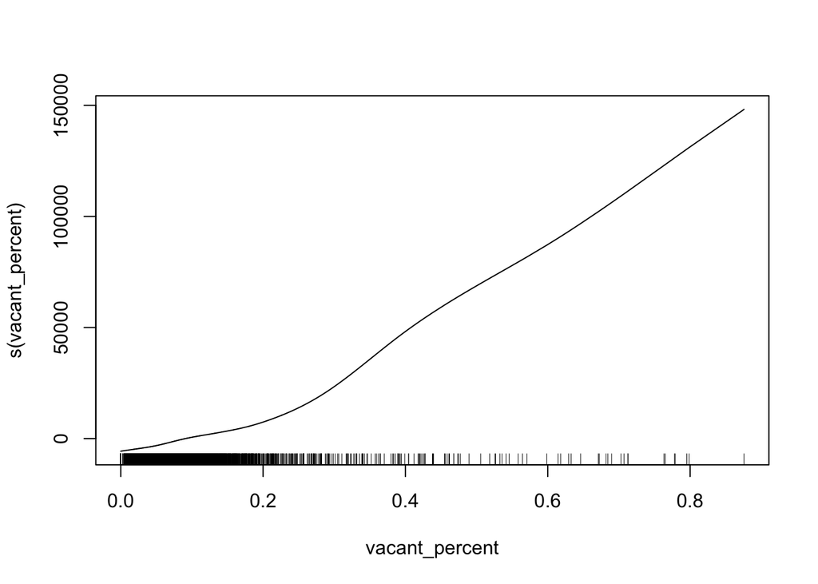

```r
plot(model)
```

The default is 0.5; setting it lower makes the model *more local*. I thought that making the spatial component smaller would help, and it certainly does. I set the final value of 0.02 by tweaking it and watching the validation error jump around. The income span is not nearly as important to the predictive power of the model so I eventually left it to the default.

# Submission

The code below assumes that you have added a prediction named `price_pred` to every row of the dataset.

```r
submit <- select(ca, obs_id, price_pred)
write_csv(submit, "class05_submit.csv")
```

Now, upload this file (ends with “.Rmd”), the HTML output (ends with “.nb.html” or “.html”), and the csv file to GitHub.